# Differential Privacy: Learn properties of a population without violating the privacy of individuals in database

##### <sup>1</sup> Department of Statistics and Data Science, Lawrence University

[figure not shown]

# Introduction

The mathematical framework and foundation of Differential Privacy was introduced by Cynthia Dwork in 2006 while she was a researcher at the Microsoft Research (Dwork 2006). This work came out of the idea that “nothing about an individual should be learnable from a database that cannot be learned without access to the database” raised by Dalenius in 1977.

Dwork wanted to show that this type of absolute privacy cannot be achieved due to auxiliary information, and proposed differential privacy as a new privacy measure that shifts the attention from absolute to relative guarantees about information disclosures. The underlying concept here is that privacy-preserving statistical database should allow users to learn properties of a population as a whole while leaving information about the individuals intact, and any given disclosure regarding an individual is just as likely whether or not they participate in the database.

## Paper Objectives

1. Prove Dalenius’s idea of Absolute Disclosure Prevention is mathematically impossible
2. Redefine privacy $\rightarrow$ Define Differential Privacy
3. Achieve Differential Privacy

# A problem with absolute disclosure: auxiliary information

Absolute disclosure states that having access to a statistical database should not enable one to learn anything about an individual that could not be learned without access to the database.

Consider a database that gives the average heights of women of different nationalities.
$$\downarrow$$
Privacy breach = Revealing the exact height of any individual.
$$\downarrow$$
Auxiliary information = “Terry Gross is two inches shorter than the average Lithuanian woman.”
$$\downarrow$$
An adversary can learn Terry Gross’s exact height.

# Earlier attempts at protecting users’ privacy

1. Forbid queries about specific individuals.(Dachman-Soled 2017)
2. Determine by analysis if a set of queries will cause disclosure: Computationally unfeasible.
3. Release only a subset of the database.
4. Add random noise to the query responses.

# What is differential privacy?

Any given disclosure will be, within a small multiplicative factor, just as likely whether or not the individual participates in the database.

`Definition:` A randomized algorithm $K$ satisfies $\epsilon$-differential privacy if for all data sets $D_1$ and $D_2$ differing on at most one element:

$$\frac{Pr(K(D_1) \in S)}{Pr(K(D_2) \in S)} \le e^{\epsilon} = R$$

The closer $R$ is to 1 (equivalent to $\epsilon$ closer to 0), the more difficult it will be for an adversary to determine an individual’s data.

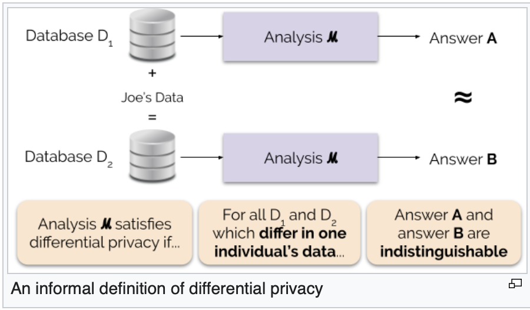

Figure 1: A diagram to demonstrate what Differential Privacy is, taken from Wikipedia

# How to achieve differential privacy?

`Definition:` For a query function $f: D\rightarrow R^d$, the L1-sensitivity of $f$ is:

$$\Delta f = max_{D,D'} \sum_{i=1}^{d}| f(D_i) - f(D'_i)|$$
for all $D, D'$ differing in at most one element.

$\Rightarrow$ The sensitivity defines the difference the noise must hide.

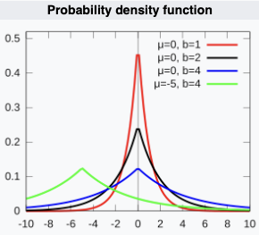

Figure 2: The Laplace Probability Distribution used to generate random noise, figure taken from Wikipedia

We can then add appropriately chosen random noise as a function of the sensitivity of the query to the answer.

Do so with Laplace Distribution by setting the spread $= \frac{\Delta f}{\epsilon}$.

1. A small $\epsilon$ gives a large spread in the distribution $\Rightarrow$ more noise.
2. A large $\Delta f$ - highly sensitive query, also gives a large spread.

$\boldsymbol{Example:}$ A user inputs a query asking “How many rows in the database satisfy a given predicate?”

**1. Determine query sensitivity:** $| f(D) - f(D')| = 1$. Thus, $\Delta f = 1$.

**2. Calibrate the randomized algorithm $K$:** Choose privacy budget of $\epsilon = 0.5$, our Laplace distribution spread becomes:
$$\text{Spread } (b) = \frac{\Delta f}{\epsilon} = \frac{1}{0.5} = 2$$
**3. The Result:** If true value = $100$, mechanism $K$ adds random noise sampled from $\text{Lap}(2)$. Instead of revealing the exact count, it safely outputs a blurred number like **$101.4$**, protecting individual presence while maintaining statistical utility.

# Conclusions

1. Trade-off between data privacy and statistical utility, works well in interactive statistical query setting.
2. Does not work well with record-level data release or collection (require very small $\epsilon$) (Domingo-Ferrer, Sánchez, and Blanco-Justicia 2021).

# References

Dachman-Soled, Dana. 2017. “Introduction to Differential Privacy.” Lecture Notes, University of Maryland.

Domingo-Ferrer, Josep, David Sánchez, and Alberto Blanco-Justicia. 2021. “The Limits of Differential Privacy (and Its Misuse in Data Release and Machine Learning).” *Communications of the ACM* 64 (12): 84–92. https://doi.org/10.1145/3433638.

Dwork, Cynthia. 2006. “Differential Privacy.” In *Automata, Languages and Programming (ICALP 2006)*, 1–12. Springer.